# Christina Lake: Import camera data, covariates, and calculate independent detections

Aidan Brushett

2025-02-14

# 0. Before you begin

Aidan Brushett M.Sc. Student University of Victoria  
School of Environmental Studies  
Email: aidanbrushett@uvic.ca

# 1. Set up workspace

## 1.1. Install packages

If you don’t already have the following packages installed, use the code below to install them.

```r
list.of.packages <- c("tidyverse", "sf", "ggplot2")
new.packages <- list.of.packages[!(list.of.packages %in% installed.packages()[,"Package"])]
if(length(new.packages)) install.packages(new.packages)
rm(new.packages, list.of.packages)
```

## 1.2. Load libraries

And a couple custom functions that can help with masking issues from package loading:

```r
rm(list=ls()) # clear environment

library(tidyverse) # data tidying, visualization, and much more; this will load all tidyverse packages, can see complete list using tidyverse_packages()
library(ggplot2) # pretty plots
library(sf) # for writing and copying files and directories

# These are functions that can sometimes get masked by other packages. Shouldn't be an issue and could be removed.
select <- dplyr::select
filter <- dplyr::filter
mutate <- dplyr::mutate
summarize <- dplyr::summarize
# Cheeky function that means "not in"
`%nin%` = Negate(`%in%`)
```

# 2. Import Christina image data

This comes straight from the Christina Lake repo (https://github.com/ACMElabUvic/Christina_Lake) and was cleaned/organized by Andrew Barnas in that location. We will only perform minimal QAQC as a result.

```r
cl_image <- read_csv("./data/raw/CL_detections_raw_2011-2020.csv",
                   # Specify column types
                   col_types = cols(site = col_factor(),
                                    treatment = col_factor(),
                                    datetime = col_datetime(format = "%Y-%m-%d %H:%M:%S"),
                                    species = col_factor())
                   ) %>%
    # Append the array prefix to all sites
    mutate(site = paste0("CL_", site) %>% as.factor()) %>%

  # Create some extra columns
  separate_wider_delim(site,
                       delim = '_',
                       names = c('array',
                                 'camera'),
                       cols_remove = FALSE) %>%

  # specify format of new columns
  mutate(
    array = as.factor(array),
    camera = as.factor(camera)
    )
```

Let’s inspect the CL data for any NAs, irregular values, or bad classes.

```r
str(cl_image)
```

```
## tibble [264,120 × 6] (S3: tbl_df/tbl/data.frame)
##  $ treatment: Factor w/ 2 levels "pre","post": 1 1 1 1 1 1 1 1 1 1 ...
##  $ array    : Factor w/ 1 level "CL": 1 1 1 1 1 1 1 1 1 1 ...
##  $ camera   : Factor w/ 65 levels "1","10","12",..: 1 1 1 1 1 1 1 1 1 1 ...
##  $ site     : Factor w/ 65 levels "CL_1","CL_10",..: 1 1 1 1 1 1 1 1 1 1 ...
##  $ datetime : POSIXct[1:264120], format: "2011-10-22 13:11:00" "2011-10-22 13:11:00" ...
##  $ species  : Factor w/ 39 levels "lynx","snowshoe hare",..: 1 1 1 1 1 1 1 1 2 2 ...
```

```r
summary(cl_image)
```

```
##  treatment     array           camera            site
##  pre :141036   CL:264120   42     : 16996   CL_42  : 16996
##  post:123084               59     : 11547   CL_59  : 11547
##                            44     : 10176   CL_44  : 10176
##                            60     :  9903   CL_60  :  9903
##                            51     :  9702   CL_51  :  9702
##                            46     :  9564   CL_46  :  9564
##                            (Other):196232   (Other):196232
##     datetime                                   species
##  Min.   :2011-10-22 13:11:00.00   white-tailed deer:216127
##  1st Qu.:2012-09-26 01:33:00.00   snowshoe hare    : 14921
##  Median :2014-06-24 02:37:30.00   human            :  9069
##  Mean   :2015-12-21 12:54:05.10   black bear       :  7055
##  3rd Qu.:2019-05-23 20:19:36.50   coyote           :  3406
##  Max.   :2020-10-18 09:11:14.00   wolf             :  2927
##                                   (Other)          : 10615
```

```r
# where are the NAs coming from?
# No NAs are present
cl_image %>% filter(is.na(datetime))
```

```
## # A tibble: 0 × 6
## # ℹ 6 variables: treatment <fct>, array <fct>, camera <fct>, site <fct>,
## #   datetime <dttm>, species <fct>
```

```r
# No sites are NA either.
levels(cl_image$site)
```

```
##  [1] "CL_1"  "CL_10" "CL_12" "CL_13" "CL_14" "CL_15" "CL_16" "CL_17" "CL_18"
## [10] "CL_19" "CL_2"  "CL_20" "CL_21" "CL_22" "CL_23" "CL_24" "CL_25" "CL_26"
## [19] "CL_27" "CL_28" "CL_29" "CL_3"  "CL_30" "CL_31" "CL_32" "CL_33" "CL_34"
## [28] "CL_35" "CL_36" "CL_37" "CL_38" "CL_39" "CL_4"  "CL_40" "CL_41" "CL_42"
## [37] "CL_43" "CL_44" "CL_45" "CL_46" "CL_47" "CL_48" "CL_49" "CL_5"  "CL_50"
## [46] "CL_51" "CL_52" "CL_53" "CL_54" "CL_55" "CL_56" "CL_57" "CL_58" "CL_59"
## [55] "CL_6"  "CL_60" "CL_61" "CL_62" "CL_63" "CL_64" "CL_65" "CL_66" "CL_7"
## [64] "CL_8"  "CL_9"
```

```r
cl_image %>% filter(is.na(site))
```

```
## # A tibble: 0 × 6
## # ℹ 6 variables: treatment <fct>, array <fct>, camera <fct>, site <fct>,
## #   datetime <dttm>, species <fct>
```

```r
# quick filter in case any cases show up, we'll just brute force remove them
cl_image <- cl_image %>%

  filter(!is.na(site),  # remove the single missing row with no camera name (not useful)
         !is.na(datetime), # remove the missing datetime stamps (92 images from one staff image event, not helpful either)
         !is.na(species)
         )

#write_csv(cl_image, "./data/raw/cl_detections_raw_2021-2023.csv")
```

Independent detections:

We will use a 30-minute independent detection threshold.

```r
mins <- 30 #30 minute threshold for independent detections
```

However, a 10-minute threshold correlated best with snowshoe hare density in this paper, so it could be worth considering at a later date:

Villette, P., Krebs, C.J. & Jung, T.S. Evaluating camera traps as an alternative to live trapping for estimating the density of snowshoe hares (Lepus americanus) and red squirrels (Tamiasciurus hudsonicus). Eur J Wildl Res 63, 7 (2017). https://doi.org/10.1007/s10344-016-1064-3

```r
cl_indet <- cl_image %>%

  drop_na(species) %>%

  arrange(site, species, datetime) %>% # must be in order for this to work.

  group_by(species, site) %>%

  # independent detections based on 30min threshold
  mutate(
    #DateTime2 = as.POSIXct(datetime), # convert to seconds. Might be redundant code, this function was embedded from previous code written by Aidan.
    timediff = c(difftime(datetime, lag(datetime),
                          units = "mins")), # time difference from prev photo
    detection_id = cumsum(if_else(is.na(timediff) | timediff > mins,  # Create episode IDs to distinguish detections
                               1,
                               0))) %>%

  ungroup() %>%

  group_by(array, camera, site, species, detection_id) %>%

  summarize(event_start = min(datetime), event_end = max(datetime)) %>%

  ungroup() %>%

  select(-detection_id) %>%

  # We will pull out the first and last timestamp of an event. This is a very coarse measure of event duration.
  mutate(year = year(event_start),
         month = month(event_start))
```

[output not shown]

```r
  # This is a filter we could apply to the detection data if we wanted. For now we'll leave it in!
#  filter(year <= 2015)

write_csv(cl_indet,
          './data/processed/CL_independent_detections_2011-2020.csv')
```

# 3. Import Christina deployment data

Import the raw deployment spreadsheet obtained from GitHub:

```r
cl_deploy <- read_csv('./data/raw/CL_deployment_2011-2020.csv',
                   col_types = cols(site = col_factor(),
                                    UTME = col_number(),
                                    UTMN = col_number(),
                                    treatment = col_factor(),
                                    start_date = col_datetime(format = "%Y-%m-%d"),
                                    end_date = col_datetime(format = "%Y-%m-%d"))
                   ) %>%

  select(-camera_check) %>%

  mutate(site = paste0("CL_", site) %>% as.factor()) %>%

  separate_wider_delim(site,
                       delim = '_',
                       names = c('array',
                                 'camera'),
                       cols_remove = FALSE) %>%

      # specify format of new columns
  mutate(
    array = as.factor(array),
    camera = as.factor(camera)
    )
```

Inspect the data:

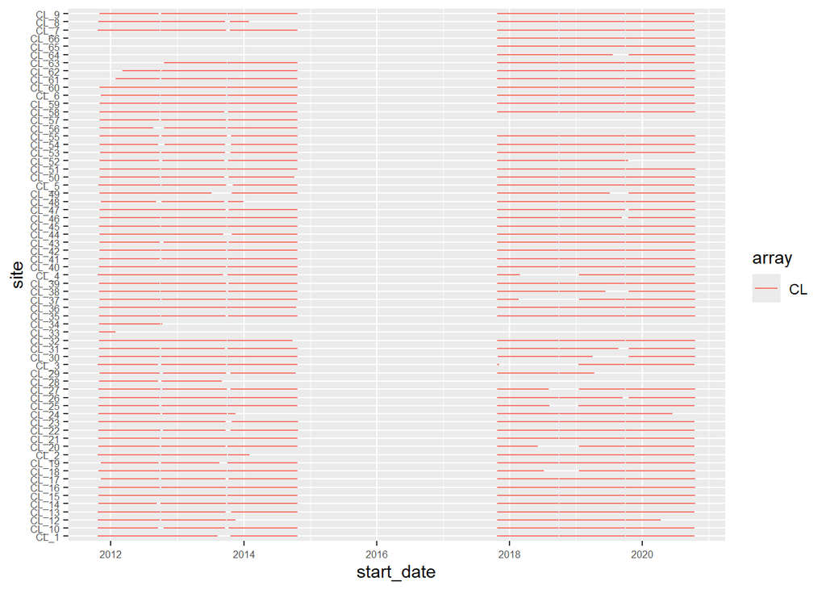

```r
# Inspect it
ggplot(cl_deploy, aes(color = array))+

  geom_segment(aes(x = start_date,
                   xend = end_date,
                   y = site,
                   yend = site)) +

  theme(axis.text = element_text(size = 6))
```

List of dates:

For my project, we are only interested in PRE-CULL DATA. Moving forward, we could use a coarse filter to remove any data, sites, covariates, or deployment dates from the post-cull period. For now, we will keep this data in. We will subset the Christina data to the data that we actually want in script 3, where we start to build our dataset for analysis.

```r
cl_operating <- cl_deploy %>%

  drop_na(start_date, end_date) %>%

  rowwise() %>%

  # create a list sequence of dates for each site from the first to the last day of operability
  mutate(date = list(seq(from = date(start_date), to = date(end_date), by="day"))) %>%

  unnest(date) %>%

  select(array, camera, site, treatment, date) # %>%

#  filter(year(date) <=2015)
```

Write the file:

```r
write_csv(cl_operating, "./data/processed/CL_operating_2011-2020.csv")
rm(cl_deploy)
```